# SI 618 Lec 02

## topics

- qplot()
- ggplot()
- plyr()

### Data Frame

- combine vectors of different types
  - numeric and string (unlike cbind, rbind)

```r
df <- data.frame(a=c(1:5), b=c("cat", "dog", "emu", "fish", "giraffe"))
df
```

|  | a | b |
| --- | --- | --- |
| 1 | 1 | cat |
| 2 | 2 | dog |
| 3 | 3 | emu |
| 4 | 4 | fish |
| 5 | 5 | giraffe |

```r
df$a
```

1. 1

2. 2

3. 3

4. 4

5. 5

```r
mydata <- data.frame(dom=c(4,5,6,8,5,6,7), nondom=c(9,10,10,14,13,12,11), Gender=c("F", "F", "F", "M","M","F","M"))
mydata
```

|  | dom | nondom | Gender |
| --- | --- | --- | --- |
| 1 | 4 | 9 | F |
| 2 | 5 | 10 | F |
| 3 | 6 | 10 | F |
| 4 | 8 | 14 | M |
| 5 | 5 | 13 | M |
| 6 | 6 | 12 | F |
| 7 | 7 | 11 | M |

```r
library(ggplot2)
```

#### 1. Two ways to inspect a dataset

- head
- str (structure)

```r
head(diamonds, 15)
```

```
   carat       cut color clarity depth table price    x    y    z
1   0.23     Ideal     E     SI2  61.5    55   326 3.95 3.98 2.43
2   0.21   Premium     E     SI1  59.8    61   326 3.89 3.84 2.31
3   0.23      Good     E     VS1  56.9    65   327 4.05 4.07 2.31
4   0.29   Premium     I     VS2  62.4    58   334 4.20 4.23 2.63
5   0.31      Good     J     SI2  63.3    58   335 4.34 4.35 2.75
6   0.24 Very Good     J    VVS2  62.8    57   336 3.94 3.96 2.48
7   0.24 Very Good     I    VVS1  62.3    57   336 3.95 3.98 2.47
8   0.26 Very Good     H     SI1  61.9    55   337 4.07 4.11 2.53
9   0.22      Fair     E     VS2  65.1    61   337 3.87 3.78 2.49
10  0.23 Very Good     H     VS1  59.4    61   338 4.00 4.05 2.39
11  0.30      Good     J     SI1  64.0    55   339 4.25 4.28 2.73
12  0.23     Ideal     J     VS1  62.8    56   340 3.93 3.90 2.46
13  0.22   Premium     F     SI1  60.4    61   342 3.88 3.84 2.33
14  0.31     Ideal     J     SI2  62.2    54   344 4.35 4.37 2.71
15  0.20   Premium     E     SI2  60.2    62   345 3.79 3.75 2.27
```

```r
str(diamonds)  # structure
```

```
Classes ‘tbl_df’, ‘tbl’ and 'data.frame':	53940 obs. of  10 variables:
 $ carat  : num  0.23 0.21 0.23 0.29 0.31 0.24 0.24 0.26 0.22 0.23 ...
 $ cut    : Ord.factor w/ 5 levels "Fair"<"Good"<..: 5 4 2 4 2 3 3 3 1 3 ...
 $ color  : Ord.factor w/ 7 levels "D"<"E"<"F"<"G"<..: 2 2 2 6 7 7 6 5 2 5 ...
 $ clarity: Ord.factor w/ 8 levels "I1"<"SI2"<"SI1"<..: 2 3 5 4 2 6 7 3 4 5 ...
 $ depth  : num  61.5 59.8 56.9 62.4 63.3 62.8 62.3 61.9 65.1 59.4 ...
 $ table  : num  55 61 65 58 58 57 57 55 61 61 ...
 $ price  : int  326 326 327 334 335 336 336 337 337 338 ...
 $ x      : num  3.95 3.89 4.05 4.2 4.34 3.94 3.95 4.07 3.87 4 ...
 $ y      : num  3.98 3.84 4.07 4.23 4.35 3.96 3.98 4.11 3.78 4.05 ...
 $ z      : num  2.43 2.31 2.31 2.63 2.75 2.48 2.47 2.53 2.49 2.39 ...
```

**Possible questions**

- how is one variable (price) distributed?
  - histogram
  - density chart
- how is diamond price related to size? clarity? color? (relationship b/w two variables)
  - scatterplot
  - boxplot
- how two variables are related conditioned on other variables ("faceting")
  - scatter plot by group
- are some diamond colors more rare than others?
- are the biggest diamonds usually high or low clarity?

**With Dataset..**

- variables
- types and ranges
  - categorical
  - ordinal
  - conti/discrete numerical
- for a single varible:
  - how do values separate into groups(clusters)?
  - do the values have an asymmetric trailing off more in one direction than others?
  - undexpectedly popular or unpopular values?
  - centered? (mean vs. median)
  - how widely spread? (max-min or sd)

#### 2. Distribution & key properties

- median
- mean
- mode (most common value)
- qurtiles : 25%, 50%, 75%
- variance
- extreme values (top 10%, bottom 90%, range)

```r
summary(diamonds)
# for categorical data, summary gives the count for each level in factors
```

```
     carat               cut        color        clarity          depth
 Min.   :0.2000   Fair     : 1610   D: 6775   SI1    :13065   Min.   :43.00
 1st Qu.:0.4000   Good     : 4906   E: 9797   VS2    :12258   1st Qu.:61.00
 Median :0.7000   Very Good:12082   F: 9542   SI2    : 9194   Median :61.80
 Mean   :0.7979   Premium  :13791   G:11292   VS1    : 8171   Mean   :61.75
 3rd Qu.:1.0400   Ideal    :21551   H: 8304   VVS2   : 5066   3rd Qu.:62.50
 Max.   :5.0100                     I: 5422   VVS1   : 3655   Max.   :79.00
                                    J: 2808   (Other): 2531
     table           price             x                y
 Min.   :43.00   Min.   :  326   Min.   : 0.000   Min.   : 0.000
 1st Qu.:56.00   1st Qu.:  950   1st Qu.: 4.710   1st Qu.: 4.720
 Median :57.00   Median : 2401   Median : 5.700   Median : 5.710
 Mean   :57.46   Mean   : 3933   Mean   : 5.731   Mean   : 5.735
 3rd Qu.:59.00   3rd Qu.: 5324   3rd Qu.: 6.540   3rd Qu.: 6.540
 Max.   :95.00   Max.   :18823   Max.   :10.740   Max.   :58.900

       z
 Min.   : 0.000
 1st Qu.: 2.910
 Median : 3.530
 Mean   : 3.539
 3rd Qu.: 4.040
 Max.   :31.800
```

### Visualization with ggplot2

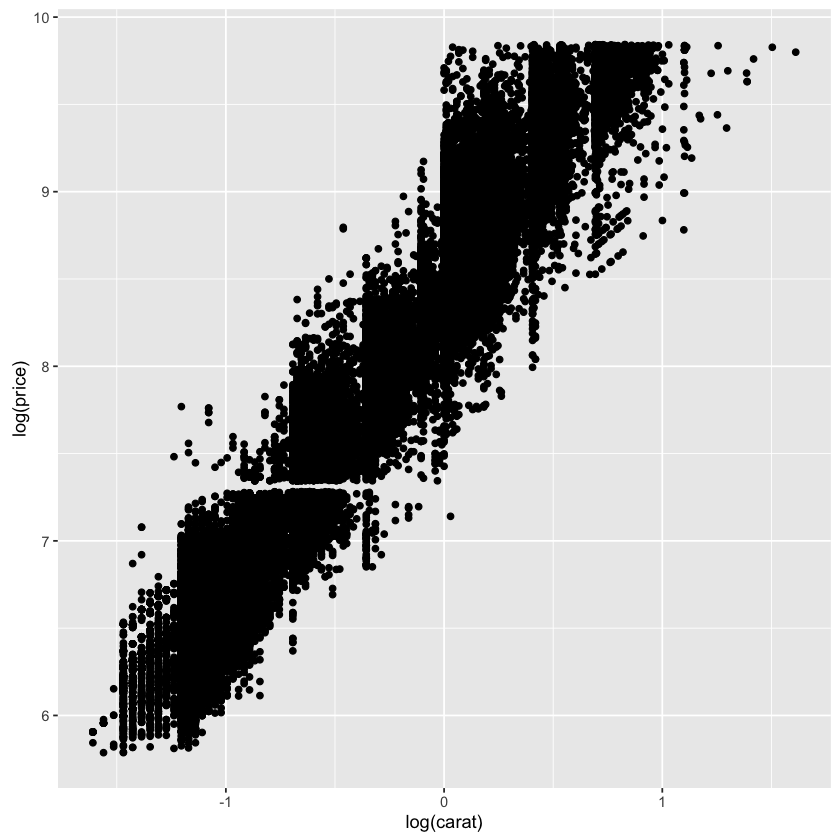

```r
attach(diamonds)
qplot(log(carat), log(price), data= diamonds)
# results:
# positive linear relationship
# empty bars (missing values)
# outliers
```

Results:

- interpreting a scatterplot
  - is there a global trend?
  - linear, curved, multi-part trend?

**Aesthetic attributes of a plot**

- each aesthetic can be mapped to a variable
  - color, shape for categorical variable
  - size for conti. variable
- each aesthetic attribute has a *scale*
  - scale maps data values to aesthetic values
  - ggplot will add a legend automatically if needed

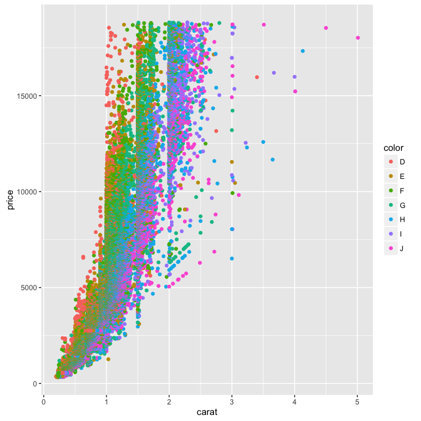

```r
qplot(carat, price, data= diamonds, colour=color)
```

```r
#qplot(carat, price, data= diamonds, size=color)  # not good
```

```r
#qplot(carat, price, data= diamonds, colour=color, size=color)  # not good since it's too dense.
```

**2. setting the alpha aesthetic (transparency)**

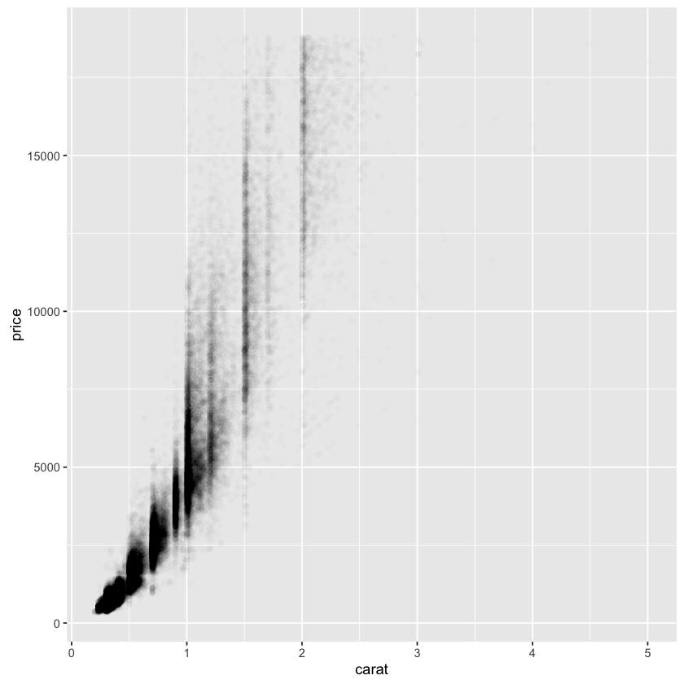

```r
qplot(carat, price, data= diamonds, alpha=I(1/100))
# I is a function/operator
```

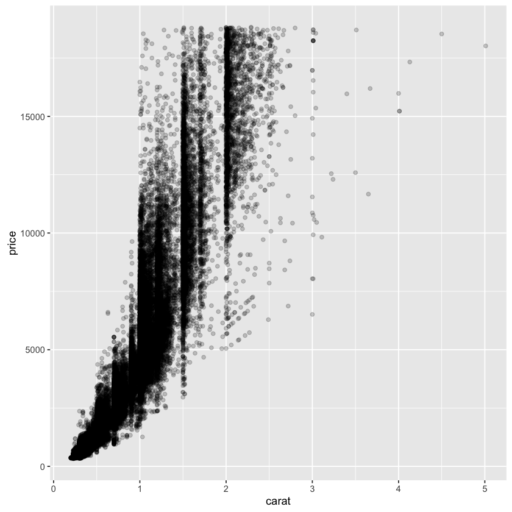

```r
qplot(carat, price, data= diamonds, alpha=I(1/5))
```

**3. Facets** show the sample plot for different subsets of the data

- can find outliers in the graph

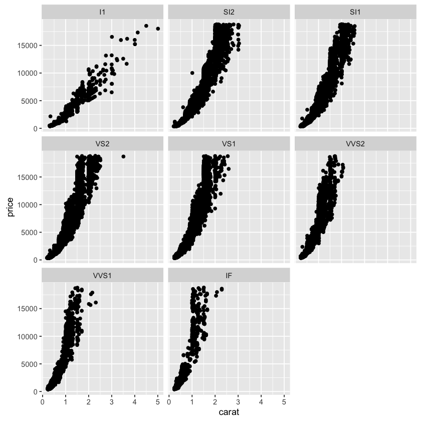

```r
qplot(carat, price, data= diamonds, facets=~clarity)
```

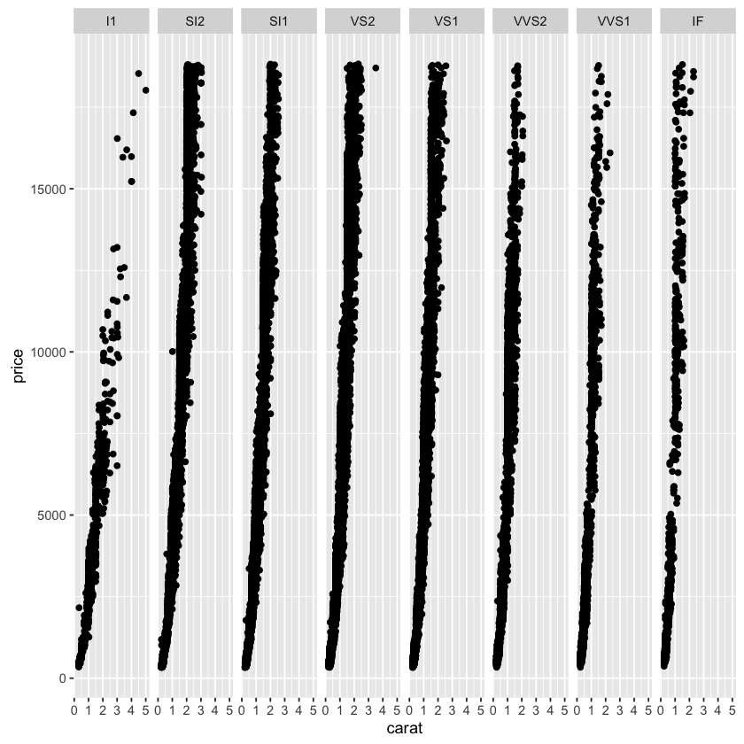

```r
qplot(carat, price, data= diamonds, facets=.~clarity)
```

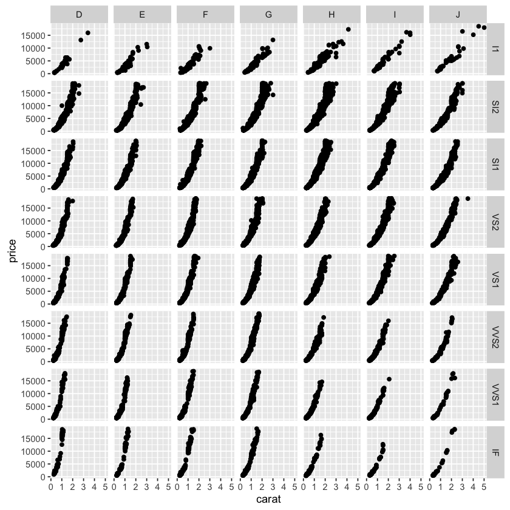

```r
qplot(carat, price, data= diamonds, facets=clarity~color)
```

- is there any interaction b/w clarity and color?

```r
#qplot(carat, price, data= diamonds, facets=color~clarity~cut)   # not helpful
```

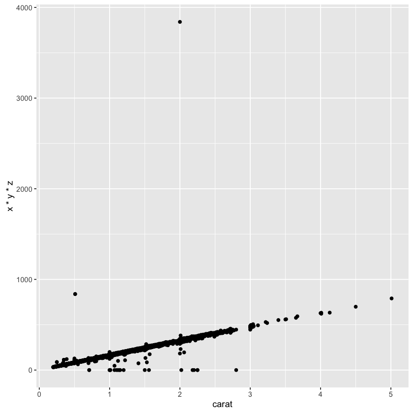

```r
qplot(carat, x*y*z, data=diamonds)
# carat = weight
# up-right trends
# outliers :
```

**4. Geometric objects in ggplot : geom=".."**

- point
- jitter
- boxplot

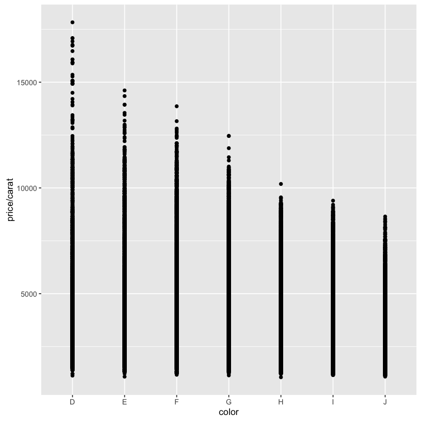

```r
qplot(color, price/carat, data=diamonds, geom="point")  # not so good
```

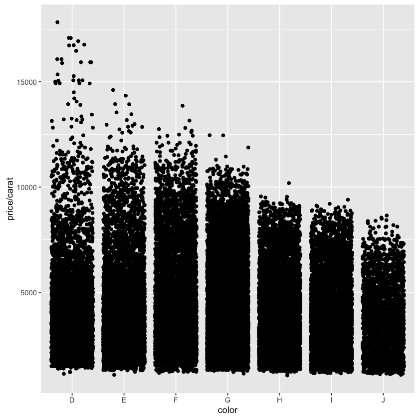

```r
qplot(color, price/carat, data=diamonds, geom="jitter")
```

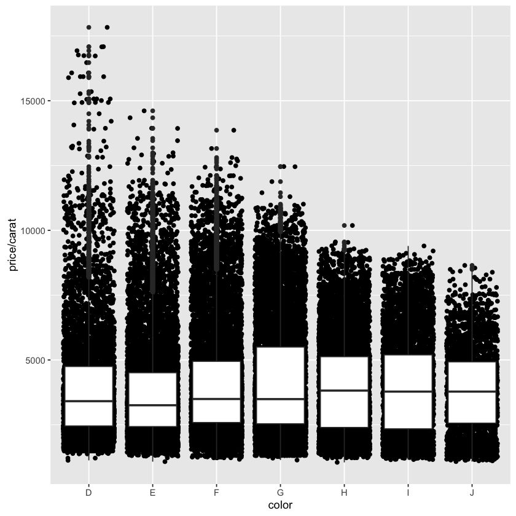

```r
# layer different plots together
qplot(color, price/carat, data=diamonds, geom=c("jitter", "boxplot"))
```

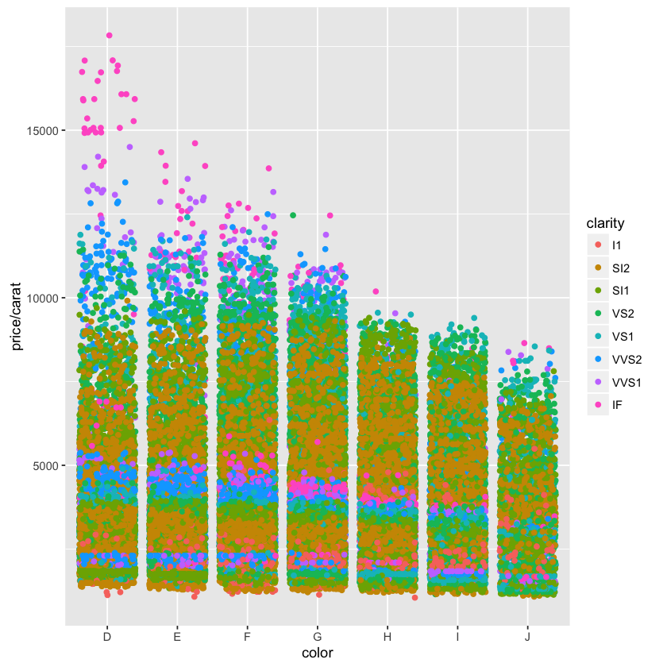

```r
qplot(color, price/carat, data=diamonds, geom="jitter", color=clarity)
```

**5. Boxplot**

- help find outliers and summarize distributions
- summrize 5 key values
  - median
  - low-hight extremem poitns
  - hinge : halfway from extreme to the median (Q1 & Q3)

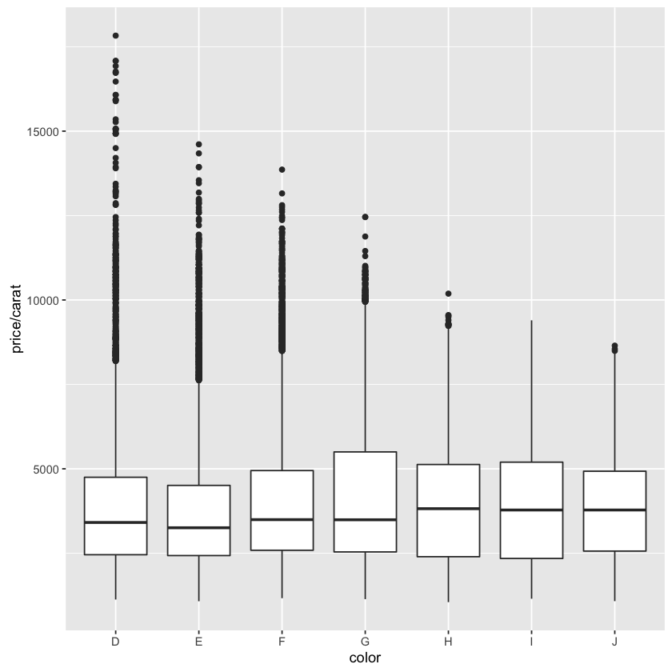

```r
qplot(color, price/carat, data=diamonds, geom="boxplot")
```

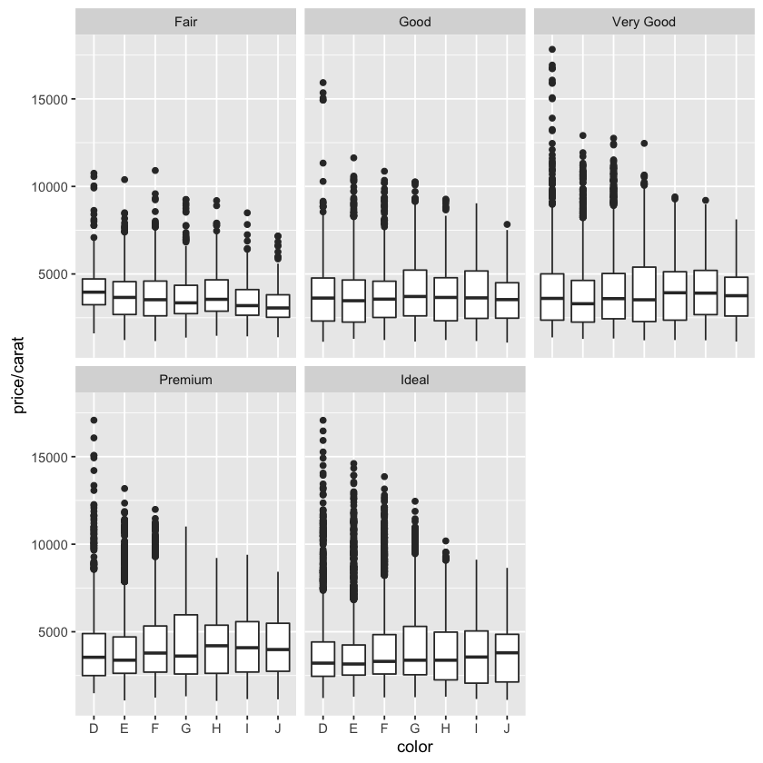

```r
qplot(color, price/carat, data=diamonds, geom="boxplot", facets=~cut)  # .~cut can generate a different display
```

- are some diamond color more rare than others?

```r
qplot(color, data=diamonds, geom="histogram")
```

[output not shown]

### Data Manipulation

- Subsets : to explore relationship b/w two varaibles
  - remove obviously 'bad' values
  - 'zoom in' on a region of interest
- transforming : adding new columns of features
- summarizing : statistics over *groups* in the data

**1. Selecting subsets using indices**

```r
# %in% let check whether values in next one
# only give first several rows if color is E or F
head(diamonds[diamonds$color %in% c("E", "F"),])
```

```
   carat     cut color clarity depth table price    x    y    z
1   0.23   Ideal     E     SI2  61.5    55   326 3.95 3.98 2.43
2   0.21 Premium     E     SI1  59.8    61   326 3.89 3.84 2.31
3   0.23    Good     E     VS1  56.9    65   327 4.05 4.07 2.31
9   0.22    Fair     E     VS2  65.1    61   337 3.87 3.78 2.49
13  0.22 Premium     F     SI1  60.4    61   342 3.88 3.84 2.33
15  0.20 Premium     E     SI2  60.2    62   345 3.79 3.75 2.27
```

```r
head(diamonds[,2:4])
```

```
        cut color clarity
1     Ideal     E     SI2
2   Premium     E     SI1
3      Good     E     VS1
4   Premium     I     VS2
5      Good     J     SI2
6 Very Good     J    VVS2
```

```r
head(diamonds[diamonds$color %in% c("E", "F"),2:4])
```

```
       cut color clarity
1    Ideal     E     SI2
2  Premium     E     SI1
3     Good     E     VS1
9     Fair     E     VS2
13 Premium     F     SI1
15 Premium     E     SI2
```

```r
# like SQL SELECT
head(subset(diamonds, price > 400 & clarity == "IF"))
# & : connect multiple conditions
# == : test equivalency
```

```
    carat       cut color clarity depth table price    x    y    z
230  0.52     Ideal     F      IF  62.2    55  2783 5.14 5.18 3.21
251  0.55     Ideal     G      IF  60.9    57  2789 5.28 5.30 3.22
257  0.64     Ideal     G      IF  61.3    56  2790 5.54 5.58 3.41
282  0.72   Premium     I      IF  63.0    57  2795 5.72 5.70 3.60
305  0.60 Very Good     G      IF  61.6    56  2800 5.43 5.46 3.35
314  0.61     Ideal     G      IF  62.3    56  2800 5.43 5.45 3.39
```

```r
# also select only several columns
head(subset(diamonds, price > 400 & clarity == "IF", select=c(carat, cut)))
```

```
    carat       cut
230  0.52     Ideal
251  0.55     Ideal
257  0.64     Ideal
282  0.72   Premium
305  0.60 Very Good
314  0.61     Ideal
```

```r
# using regular expression -> grepl function
# print out if "VV" in clarity
head(subset(diamonds, grepl('VV', clarity)))
```

```
   carat       cut color clarity depth table price    x    y    z
6   0.24 Very Good     J    VVS2  62.8  57.0   336 3.94 3.96 2.48
7   0.24 Very Good     I    VVS1  62.3  57.0   336 3.95 3.98 2.47
26  0.23 Very Good     G    VVS2  60.4  58.0   354 3.97 4.01 2.41
66  0.28     Ideal     G    VVS2  61.4  56.0   553 4.19 4.22 2.58
67  0.32     Ideal     I    VVS1  62.0  55.3   553 4.39 4.42 2.73
70  0.24   Premium     E    VVS1  60.7  58.0   553 4.01 4.03 2.44
```

```r
head(subset(diamonds, grepl('VS', clarity)))
```

```
   carat       cut color clarity depth table price    x    y    z
3   0.23      Good     E     VS1  56.9    65   327 4.05 4.07 2.31
4   0.29   Premium     I     VS2  62.4    58   334 4.20 4.23 2.63
6   0.24 Very Good     J    VVS2  62.8    57   336 3.94 3.96 2.48
7   0.24 Very Good     I    VVS1  62.3    57   336 3.95 3.98 2.47
9   0.22      Fair     E     VS2  65.1    61   337 3.87 3.78 2.49
10  0.23 Very Good     H     VS1  59.4    61   338 4.00 4.05 2.39
```

```r
detach(diamonds)
```

**2. slicing and dicing data frames with plyr ('plier')**

```r
library(plyr)
```

```r
bnames <- read.csv("/Users/youngjinheo/Dropbox/2016_fall/SI_618_Exploratory_Analysis/SI618_Lecture_Notes/Week2/examples-week2/bnames.csv", stringsAsFactors = FALSE)
```

```r
head(bnames, 15)
```

|  | year | name | percent | sex |
| --- | --- | --- | --- | --- |
| 1 | 1880 | John | 0.081541 | boy |
| 2 | 1880 | William | 0.080511 | boy |
| 3 | 1880 | James | 0.050057 | boy |
| 4 | 1880 | Charles | 0.045167 | boy |
| 5 | 1880 | George | 0.043292 | boy |
| 6 | 1880 | Frank | 0.02738 | boy |
| 7 | 1880 | Joseph | 0.022229 | boy |
| 8 | 1880 | Thomas | 0.021401 | boy |
| 9 | 1880 | Henry | 0.020641 | boy |
| 10 | 1880 | Robert | 0.020404 | boy |
| 11 | 1880 | Edward | 0.019965 | boy |
| 12 | 1880 | Harry | 0.018175 | boy |
| 13 | 1880 | Walter | 0.014822 | boy |
| 14 | 1880 | Arthur | 0.013504 | boy |
| 15 | 1880 | Fred | 0.013251 | boy |

```r
head(bnames, 15)
```

[output not shown]

**group-wise transforms and summaries**

- like SQL GROUP BY statement
- like map-reduce
- example
  - rank of baby name within given year and sex

**enter ddply**

```r
# input data, how to split input, function to apply to each piece, 2nd arg to transform
bnames <- ddply(bnames, c("sex", "year"), transform, rank = rank(~percent, ties.method = "first"))
```

[output not shown]

**regular expression**

- example : interesting whole-dataset transforms and summaries

```r
vowels <- function(x){
    nchar(gsub("[^AEIOUaeiou]", "", x))
    # nsub : counts of # of each letter
    # gsub : global string replace using regular expression
}
```

```r
help(nchar)  # count the number of characters
```

```r
help(gsub)  # Pattern Matching and Replacement
```

```r
vowels("Christopher")
```

3

```r
letter <- function (x, n=1){
    if (n < 0){
        nc <- nchar(x)
        n <- nc + n + 1
        }
    tolower(substr(x, n,n))
}
```

```r
bnames.ddply <- ddply(bnames, c("sex", "year"), trnasform, rank = rank)
```

```r
ddply(diamonds, )
```

**ddply is part of a family of plyr functions (refer to a table in ppt)**

**Missing data**

- represented as **NA**
- check : complete() function
- if missing values are 999, then re-code 999 to NA
  - data <- ifelse(orig.data == 999, NA, orig.data)
- delete any records that contain NA values

**Summary lecture**

- basic of qplot
- facets and how to plot them
- summary statistics, scatterplots and boxplots